# Grob Layout Customization

Calvin Floyd

2025-06-25

- Arguably the most crucial function in grobblR is `grob_layout()`, which needs to be utilized in order to create the final PDF.
- `grob_layout()` reads the grob-row’s and grob-columns within it to know how to *layout* the page. See the grobblR vignette for information on how it allots space to the grob-rows and grob-columns.
- There are many ways customize individual grob-rows and grob-columns within the grob-layout, including borders, titles and captions.

```r
library(grobblR)
```

## Borders

- Within `grob_layout()`, the `grob_row()` and `grob_col()` functions are able to put borders around their contents.

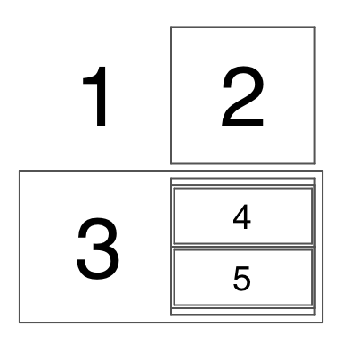

```r
grob_layout(
  grob_row(
    grob_col(1),
    grob_col(border = TRUE, 2)
    ),
  grob_row(
    border = TRUE,
    grob_col(3),
    grob_col(
      border = TRUE,
      grob_row(border = TRUE, grob_col(border = TRUE, 4)),
      grob_row(border = TRUE, grob_col(border = TRUE, 5))
      )
    ),
  height = 100,
  width = 100
  ) %>%
  view_grob()
```

- Those borders are customizable. With the `border_aes_list` argument and the `ga_list()` function, the user can adjust
  - Which border sides to display (`border_sides`)
  - The border width (`border_width`)
  - The border color (`border_color`)
- For more information on the aesthetics above, see `?ga_list`.

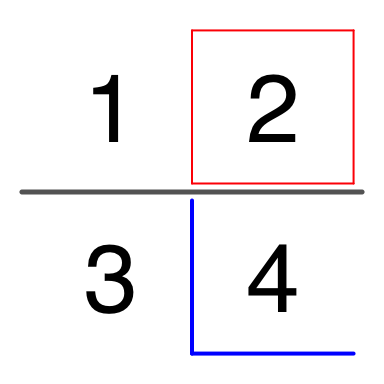

```r
grob_layout(
  grob_row(
    grob_col(1),
    grob_col(
      border = TRUE,
      border_aes_list = ga_list(
        border_color = "red"
        ),
      2
      )
    ),
  grob_row(
    border = TRUE,
    border_aes_list = ga_list(
      border_sides = "top",
      border_width = 5
      ),
    grob_col(3),
    grob_col(
      border = TRUE,
      border_aes_list = ga_list(
        border_sides = "left, bottom",
        border_color = "blue",
        border_width = 4
        ),
      4
      )
    ),
  height = 100,
  width = 100
  ) %>%
  view_grob()
```

## Titles

- Titles can be added to either `grob_layout()`, `grob_row()` or `grob_col()`.

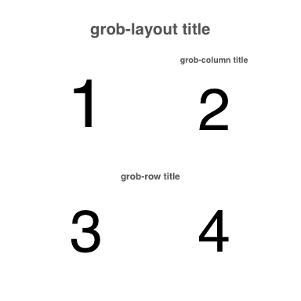

```r
grob_layout(
  title = "grob-layout title",
  grob_row(
    grob_col(1),
    grob_col(title = "grob-column title", 2)
    ),
  grob_row(
    title = "grob-row title",
    grob_col(3),
    grob_col(4)
    )
  ) %>%
  view_grob(height = 100, width = 100)
```

- The height of the title can be adjusted by either giving an explicit height in millimeters to the `title_height` argument, or changing the title height proportion with `title_p`.
  - `title_p` corresponds to the proportion of the height allotted to the grob in question which will be given to the title.
  - `title_height` will override `title_p` in all cases.

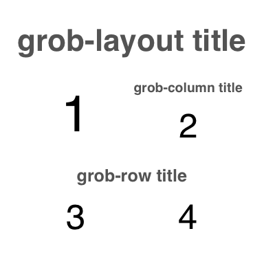

```r
grob_layout(
  title = "grob-layout title",
  title_height = 20,
  grob_row(
    grob_col(1),
    grob_col(
      title = "grob-column title",
      title_p = 0.5,
      2
      )
    ),
  grob_row(
    title = "grob-row title",
    title_height = 10,
    grob_col(3),
    grob_col(4)
    )
  ) %>%
  view_grob(height = 100, width = 100)
```

- The aesthetics of the title can be altered as well with the `title_aes_list` argument and `ga_list()`.

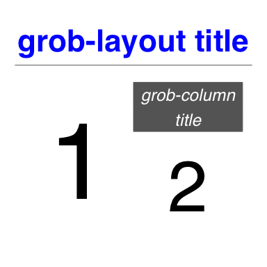

```r
grob_layout(
  title = "grob-layout title",
  title_height = 20,
  title_aes_list = ga_list(
    text_color = "blue",
    border_sides = "bottom"
    ),
  grob_row(
    grob_col(1),
    grob_col(
      title = "grob-column title",
      title_p = 0.5,
      title_aes_list = ga_list(
        font_face = 3,
        text_color = "white",
        background_color = "gray40"
        ),
      2
      )
    )
  ) %>%
  view_grob(height = 100, width = 100)
```

## Captions

- Everything that applies to titles also applies to captions, as `grob_layout()`, `grob_col()` and `grob_row()` are all equipped with `caption`, `caption_aes_list`, `caption_p` and `caption_height` arguments.
- By default, captions are more subtle than titles, but their appearances can be altered however the user wants.

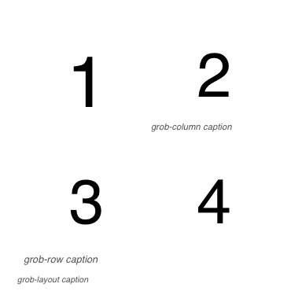

```r
grob_layout(
  caption = "grob-layout caption",
  grob_row(
    grob_col(1),
    grob_col(caption = "grob-column caption", 2)
    ),
  grob_row(
    caption = "grob-row caption",
    grob_col(3),
    grob_col(4)
    )
  ) %>%
  view_grob(height = 100, width = 100)
```

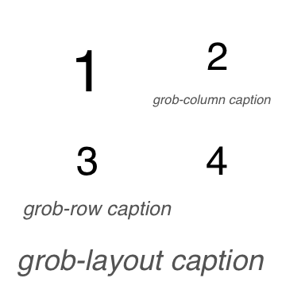

```r
grob_layout(
  caption = "grob-layout caption",
  caption_height = 20,
  grob_row(
    grob_col(1),
    grob_col(
      caption = "grob-column caption",
      caption_p = 0.5,
      2
      )
    ),
  grob_row(
    caption = "grob-row caption",
    caption_height = 10,
    grob_col(3),
    grob_col(4)
    )
  ) %>%
  view_grob(height = 100, width = 100)
```

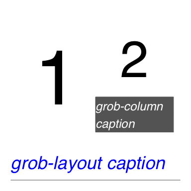

```r
grob_layout(
  caption = "grob-layout caption",
  caption_height = 20,
  caption_aes_list = ga_list(
    text_color = "blue",
    border_sides = "bottom"
    ),
  grob_row(
    grob_col(1),
    grob_col(
      caption = "grob-column caption",
      caption_p = 0.5,
      caption_aes_list = ga_list(
        font_face = 3,
        text_color = "white",
        background_color = "gray40"
        ),
      2
      )
    )
  ) %>%
  view_grob(height = 100, width = 100)
```

## Page Numbers

- The user can add a page number to the bottom right of the page if he/she wishes, by utilizing the `page_number` argument within `grob_layout()`.
- The page number is inserted into the padding of the overall grob-layout.
- As of now, the aesthetics of the page number is restricted to the default behavior.

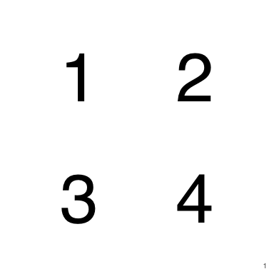

```r
grob_layout(
  grob_row(
    grob_col(1),
    grob_col(2)
    ),
  grob_row(
    grob_col(3),
    grob_col(4)
    ),
  page_number = 1
  ) %>%
  view_grob(height = 100, width = 100)
```

- FYI - The page number allotted space is more meant for a fully-sized grob-layout (using default grob-layout size) than it is for a 100mm x 100mm sized grob.